[figure not shown]

# 2 / 13: Relational Model: Overview

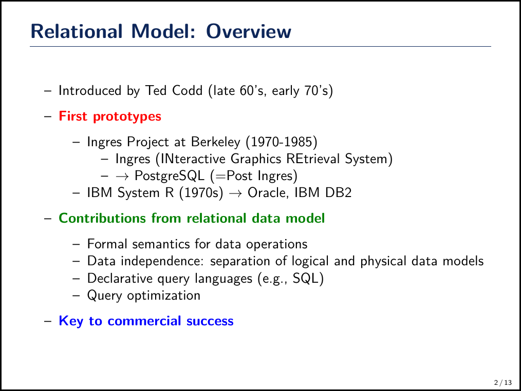

- **Relational Model: Overview**
  - The relational model was introduced by Ted Codd in the late 1960s and early 1970s. This model revolutionized how databases were structured and accessed, laying the groundwork for modern database systems.
- **First prototypes**
  - The Ingres Project at Berkeley, which ran from 1970 to 1985, was one of the first implementations of the relational model. Ingres stands for INteractive Graphics REtrieval System and was a pioneering project that eventually led to the development of PostgreSQL, a widely used database system today.
  - IBM System R was another early implementation in the 1970s. It was a research project that significantly influenced the development of commercial database systems like Oracle and IBM DB2.
- **Contributions from relational data model**
  - The relational model provided formal semantics for data operations, which means it defined a clear and mathematical way to handle data.
  - It introduced the concept of data independence, allowing the separation of logical data models (how data is organized) from physical data models (how data is stored), making databases more flexible and easier to manage.
  - Declarative query languages, such as SQL, emerged from this model, enabling users to specify what data they want without detailing how to retrieve it.
  - Query optimization became possible, allowing databases to efficiently execute queries by determining the best way to access and process data.
- **Key to commercial success**
  - The relational model’s ability to provide a structured and efficient way to manage data was crucial to its widespread adoption in commercial applications. Its principles continue to underpin many modern database systems.

# 3 / 13: Relational Model: Key Definitions

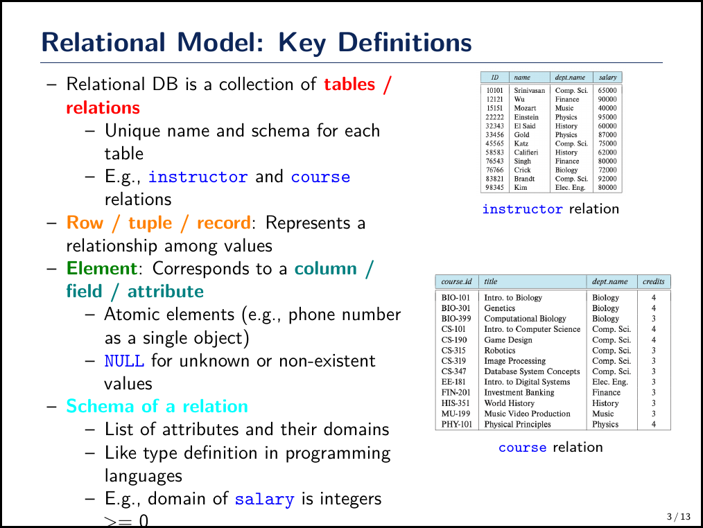

- **Relational DB is a collection of tables / relations**: In a relational database, data is organized into tables, also known as relations. Each table has a unique name and a defined structure, called a schema. For example, you might have tables named `instructor` and `course`, each with its own set of columns and data types.
- **Row / tuple / record**: Each row in a table represents a single, complete set of related data. Think of it as a single entry in a table that connects different pieces of information, like a row in the `instructor` table that includes an instructor’s ID, name, and department.
- **Element**: This refers to the individual data points within a row, corresponding to columns or fields. Each element is atomic, meaning it holds a single piece of data, like a phone number. If data is missing or unknown, it is represented by `NULL`.
- **Schema of a relation**: The schema defines the structure of a table, listing all the attributes (columns) and their data types or domains. It’s similar to a type definition in programming, ensuring that data fits expected formats, like ensuring a `salary` is always a non-negative integer.
- **Instance of relation**: This is a snapshot of the table at a particular moment, filled with actual data. As data is added, removed, or updated, the instance of the relation changes over time, reflecting the current state of the database.

The images on the right visually represent the `instructor` and `course` tables, showing how data is organized in a relational database.

# 4 / 13: UML Class Diagram

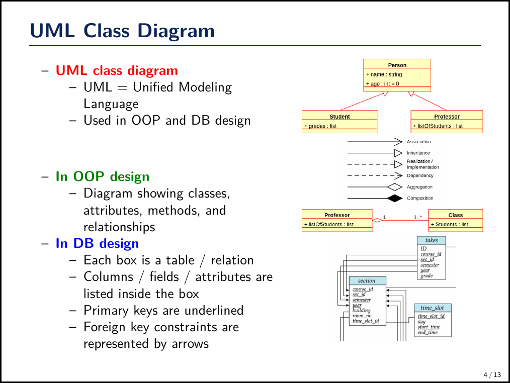

- **UML class diagram**
  - UML stands for *Unified Modeling Language*, which is a standardized way to visualize the design of a system.
  - It is commonly used in *Object-Oriented Programming (OOP)* and database (DB) design to help developers and designers understand the structure and relationships within a system.
- **In OOP design**
  - A UML class diagram is a visual representation that shows the classes in a system, along with their attributes (properties) and methods (functions).
  - It also illustrates the relationships between different classes, such as inheritance, association, and dependency, which helps in understanding how different parts of the system interact with each other.
- **In DB design**
  - In the context of database design, each box in a UML class diagram represents a table or a relation.
  - Inside each box, the columns or fields of the table are listed, which are also known as attributes.
  - Primary keys, which uniquely identify each record in a table, are underlined to distinguish them from other attributes.
  - Foreign key constraints, which establish relationships between tables, are depicted by arrows pointing from one table to another, indicating how tables are linked.

This slide provides a foundational understanding of how UML class diagrams are used in both software and database design, emphasizing their role in visualizing and organizing complex systems.

# 5 / 13: Example: University DB

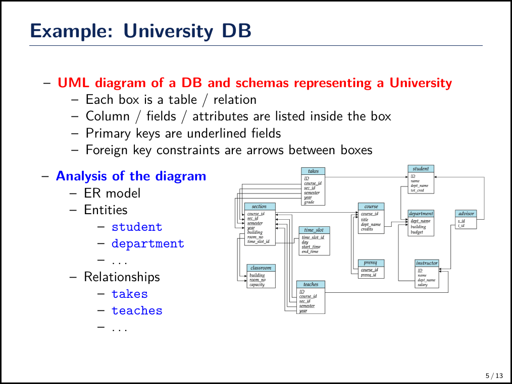

- **UML diagram of a DB and schemas representing a University**
  - The diagram is a visual representation of a database using UML (Unified Modeling Language). It helps us understand how data is organized within a university’s database.
  - **Each box is a table / relation**: In the diagram, each box represents a table in the database. A table is a collection of related data entries, similar to a spreadsheet.
  - **Column / fields / attributes are listed inside the box**: Inside each box, you’ll see a list of fields or attributes. These are the individual pieces of data stored in the table, like a student’s name or ID.
  - **Primary keys are underlined fields**: A primary key is a unique identifier for each record in a table. It’s underlined in the diagram to show its importance.
  - **Foreign key constraints are arrows between boxes**: Arrows indicate relationships between tables. A foreign key in one table points to a primary key in another, linking the data.
- **Analysis of the diagram**
  - **ER model**: The diagram is based on an Entity-Relationship (ER) model, which is a way to visually represent data and its relationships.
  - **Entities**: These are the main objects or concepts in the database. For example:
    - `student`: Represents students in the university.
    - `department`: Represents different departments within the university.
    - …: There are likely more entities, each representing a different aspect of the university.
  - **Relationships**: These show how entities are connected. For example:
    - `takes`: Represents the relationship between students and the courses they enroll in.
    - `teaches`: Represents the relationship between instructors and the courses they teach.
    - …: Additional relationships help define how entities interact with each other.

# 6 / 13: Primary Key

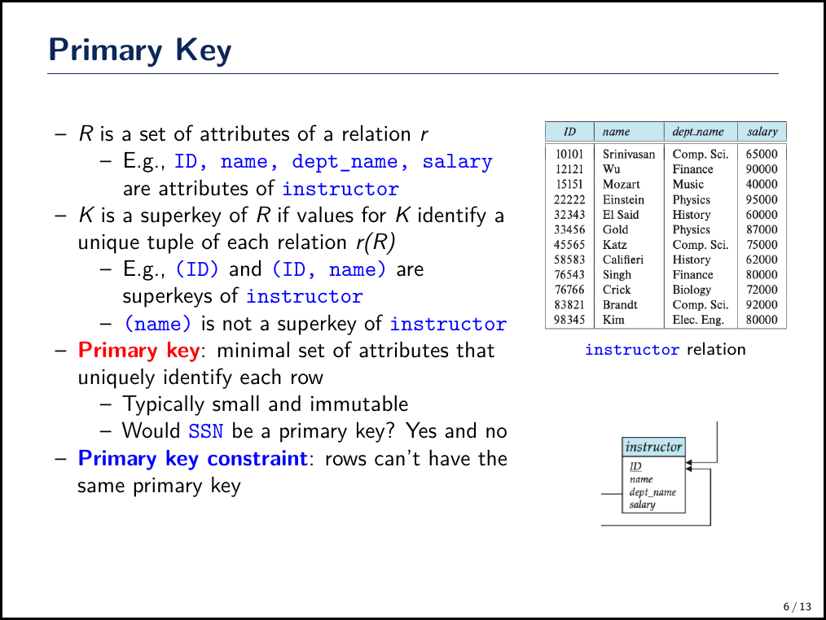

- *R* is a set of attributes of a relation *r*: In databases, a relation is like a table, and attributes are the columns in that table. For example, in an `instructor` table, the columns might be `ID`, `name`, `dept_name`, and `salary`. These columns hold specific types of data for each instructor.
- *K* is a superkey of *R*: A superkey is a set of one or more columns that can uniquely identify any row in the table. For instance, in the `instructor` table, the `ID` column alone can uniquely identify each instructor, making it a superkey. Even a combination like `(ID, name)` is a superkey, but it’s not minimal. However, just `name` isn’t a superkey because multiple instructors could have the same name.
- **Primary key**: This is the smallest set of columns that can uniquely identify each row in the table. It’s important for a primary key to be small and not change over time. For example, a Social Security Number (SSN) could be a primary key because it’s unique to each person, but it might not be ideal due to privacy concerns.
- **Primary key constraint**: This rule ensures that no two rows in the table can have the same primary key value. This is crucial for maintaining the uniqueness of each row in the database, preventing duplicate entries.

# 7 / 13: Question: What Are Primary Keys?

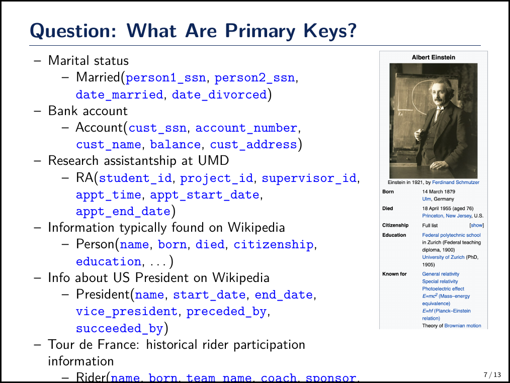

# 8 / 13: Answer: What Are Primary Keys?

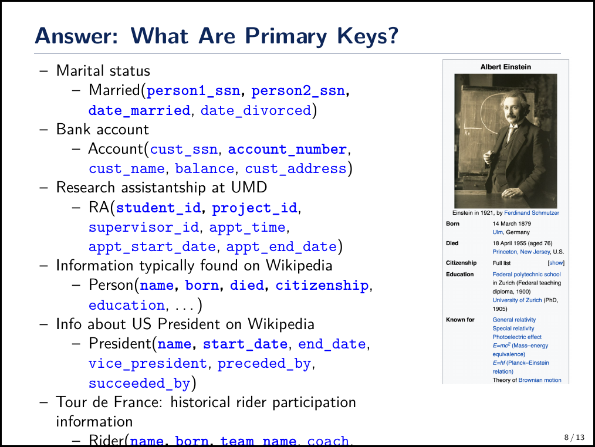

In summary, primary keys are crucial in databases as they uniquely identify each record, ensuring data integrity and efficient data retrieval.

# 9 / 13: Foreign Key

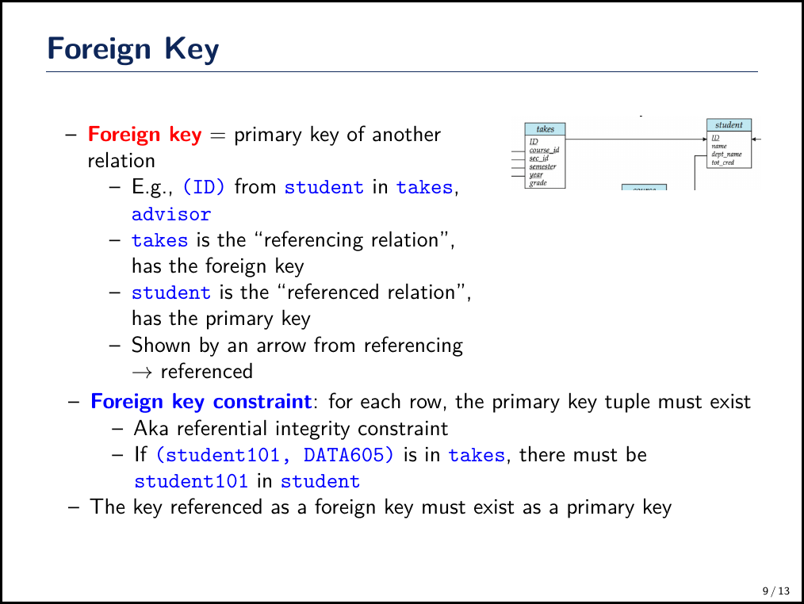

- **Foreign key**: This is a concept in databases where a column (or a set of columns) in one table is used to refer to the primary key of another table.
  - For example, if you have a column `(ID)` in a table called `takes`, it might be used to refer to the `ID` in another table called `student`. This means that the `ID` in `takes` is a foreign key.
  - The table `takes` is known as the “referencing relation” because it contains the foreign key.
  - The table `student` is the “referenced relation” because it contains the primary key that the foreign key points to.
  - This relationship is often depicted with an arrow pointing from the referencing table to the referenced table.
- **Foreign key constraint**: This is a rule that ensures data integrity between tables.
  - Also known as the referential integrity constraint, it requires that for every foreign key value in the referencing table, there must be a corresponding primary key value in the referenced table.
  - For instance, if there is an entry `(student101, DATA605)` in the `takes` table, there must be a corresponding `student101` entry in the `student` table.
  - This ensures that the foreign key always points to a valid, existing primary key in the referenced table.

# 10 / 13: Relational Algebra: 1/4

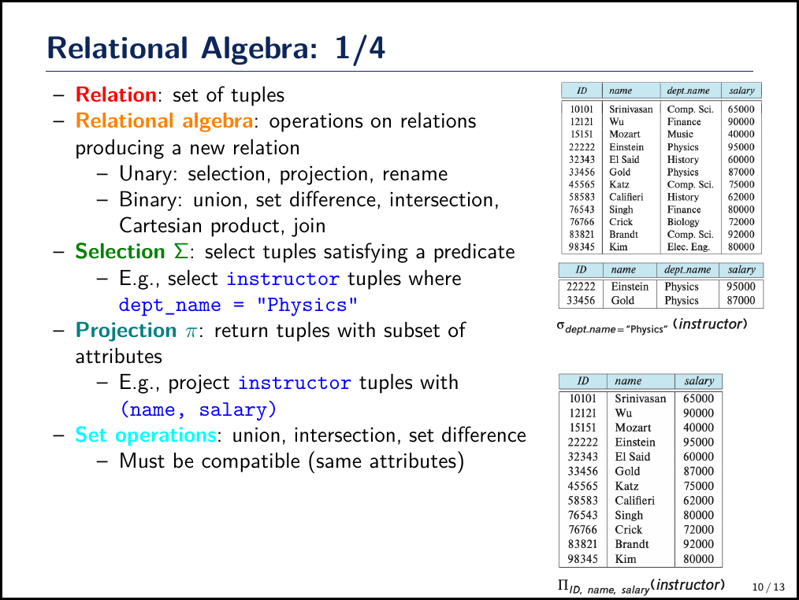

- **Relation**: In the context of databases, a *relation* is essentially a table. Each table consists of rows, known as *tuples*, and columns, which are the attributes of the data. Think of a relation as a structured way to store data where each row represents a unique data entry.
- **Relational algebra**: This is a set of operations used to manipulate and query data stored in relations. The result of these operations is always a new relation. Relational algebra is foundational for understanding how queries are processed in databases.
  - **Unary operations**: These operations work on a single relation.
    - *Selection* (*Σ*) filters rows based on a condition.
    - *Projection* (*π*) selects specific columns from the relation.
    - *Rename* changes the name of the relation or its attributes.
  - **Binary operations**: These require two relations.
    - *Union* combines rows from two relations.
    - *Set difference* finds rows in one relation but not the other.
    - *Intersection* finds common rows between two relations.
    - *Cartesian product* pairs each row of one relation with every row of another.
    - *Join* combines rows from two relations based on a related attribute.
- **Selection *Σ***: This operation is used to filter data. For example, if you want to find all instructors in the Physics department, you would use a selection operation to filter out only those rows where the department name is “Physics”.
- **Projection *π***: This operation is used to narrow down the columns of interest. For instance, if you only need the names and salaries of instructors, you would project these two attributes from the instructor relation.
- **Set operations**: These operations allow you to combine or compare two relations. It’s important that the relations involved have the same attributes to ensure compatibility. This is similar to how you might combine or compare sets in mathematics.

# 11 / 13: Relational Algebra: 2/4

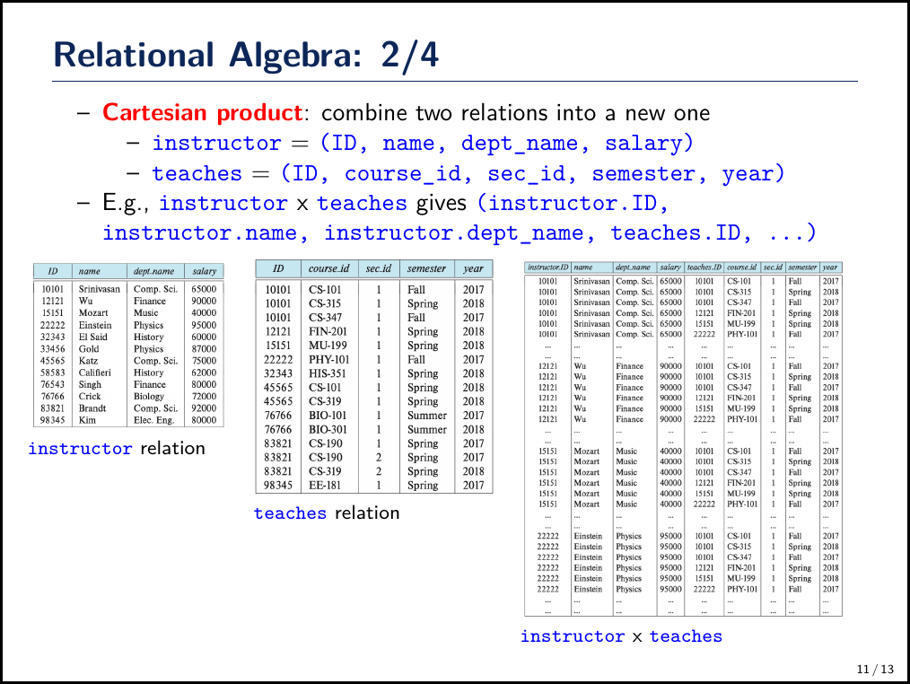

- **Cartesian product**: This operation is a fundamental concept in relational algebra, which is a part of database theory. It allows us to combine two tables (or relations) into a single new table. The new table contains all possible combinations of rows from the original tables.
  - In this example, we have two relations: `instructor` and `teaches`. The `instructor` relation includes columns for `ID`, `name`, `dept_name`, and `salary`. The `teaches` relation includes columns for `ID`, `course_id`, `sec_id`, `semester`, and `year`.
- When we perform a Cartesian product of `instructor` and `teaches`, we create a new relation that includes every possible pairing of rows from these two tables. This means that for each row in the `instructor` table, it is paired with every row in the `teaches` table. The resulting table will have columns from both tables, such as `instructor.ID`, `instructor.name`, `instructor.dept_name`, `teaches.ID`, and so on.
- **Visual aids**: The images provided in the slide show the `instructor` and `teaches` relations separately, and then the result of their Cartesian product. This visual representation helps in understanding how the Cartesian product operation combines the data from both tables into a larger set of data.
- *Important note*: While the Cartesian product is a powerful tool, it can result in very large tables, especially if the original tables have many rows. This is because the number of rows in the resulting table is the product of the number of rows in the original tables.

# 12 / 13: Relational Algebra: 3/4

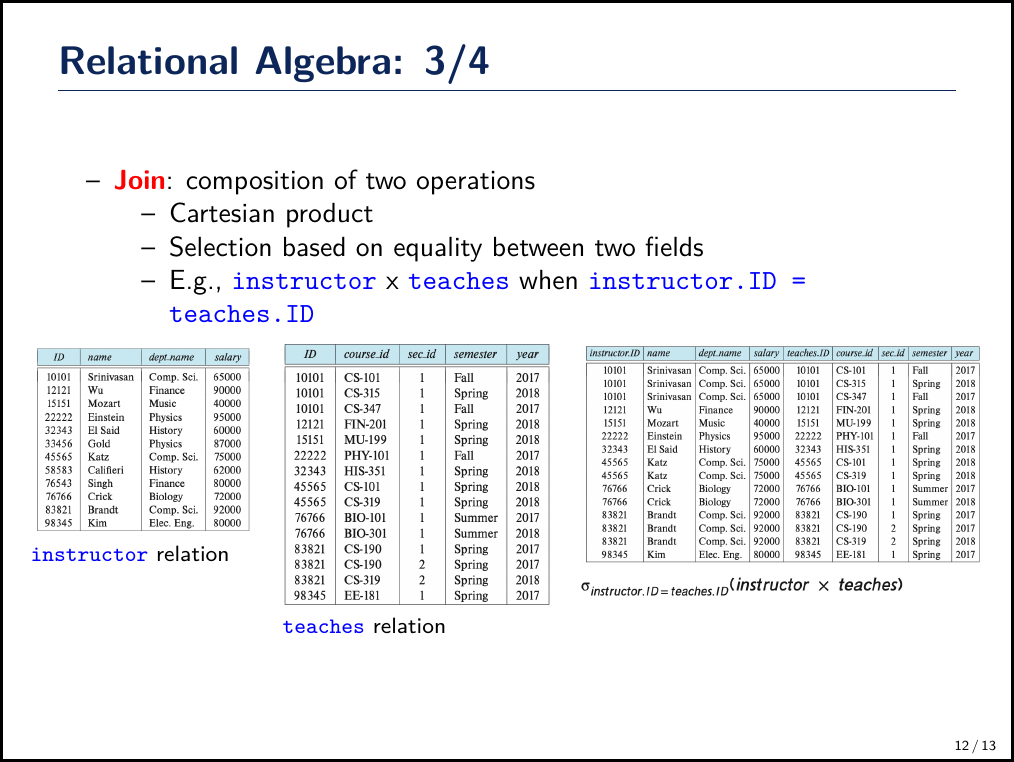

- **Join**: composition of two operations
  - The *join* operation in relational algebra is a fundamental concept used to combine two tables based on a related column. It is essentially a combination of two operations: the Cartesian product and selection.
  - **Cartesian product**: This operation takes two tables and pairs every row from the first table with every row from the second table. While this creates a large number of combinations, it is not very useful on its own because it doesn’t consider any relationships between the data.
  - **Selection based on equality between two fields**: After the Cartesian product, the selection operation is applied to filter the results. This selection is based on a condition, typically an equality between two fields from the different tables. For example, if we have an `instructor` table and a `teaches` table, we might join them on the condition that `instructor.ID = teaches.ID`. This means we only keep the rows where the instructor’s ID matches the ID in the teaches table, effectively linking instructors to the courses they teach.
  - The images in the slide likely show examples of the `instructor` and `teaches` relations, as well as the result of the join operation, illustrating how the data is combined based on the specified condition.

# 13 / 13: Relational Algebra: 4/4

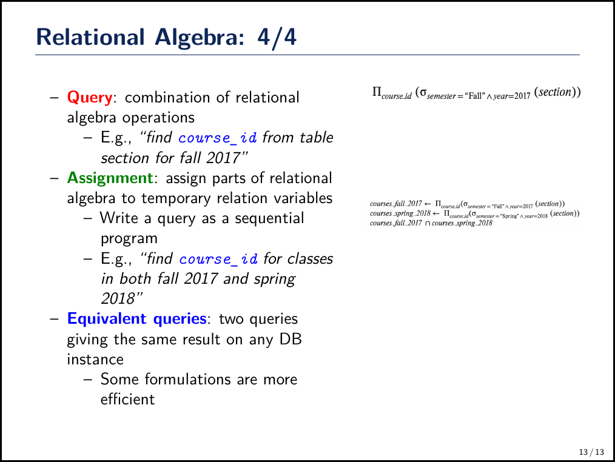

- **Query**: In relational algebra, a query is essentially a combination of operations that allow us to retrieve specific data from a database. For example, if you want to find the `course_id` from a table named `section` for the fall of 2017, you would use a series of operations to filter and select the relevant data. This is similar to asking a question to the database and getting the answer in the form of data.
- **Assignment**: Sometimes, it’s useful to break down complex queries into smaller parts. This is where assignment comes in. You can assign parts of your query to temporary variables, making it easier to manage and understand. Think of it like writing a step-by-step program where each step builds on the previous one. For instance, if you want to find `course_id` for classes in both fall 2017 and spring 2018, you might first find each separately and then combine the results.
- **Equivalent queries**: In relational algebra, different queries can sometimes produce the same result. These are known as equivalent queries. However, not all equivalent queries are created equal—some are more efficient than others. This means they can retrieve the same data faster or with less computational effort, which is important for optimizing database performance.